# Problem Details

> Assume your avocado data collection is on a 1 month delay. When predicting the price of an avocado at time x, you can only use historical data from up until 1 month prior to x)

> **Setup** : We need to bui;d dataset from the given to perform this type of modeling. A model should be trained on records which uses features based on historical data one month prior to current time. In order to create that dataset, from the original dataset, grouped by region and type shift all the numerical columns by 5 records(5 weeks, approx month). Now each record has feature values only of a month prior and at any point in time only information prior to month is being used

> **Features**: Model(XGBoost) conventional and organic separartely,
> > - Label encode region as numerical variable.
> > - Add lags of price values from month prior
> > - Add long term and short term moving average to capture trend
> > - Add month and day variable from date to capture seasonality

> **Evaluation**: Time series cross validation, split data into train and test using the date variable. Use RMSE to evaluate. Used gridsearch to get the parameter values for the xgboost model

# Import Packages

```python
# import packages for data manipulation
import pandas as pd
import numpy as np

# Plotting libraries
import matplotlib
import matplotlib.pyplot as plt
import seaborn as sns
%matplotlib inline
import janitor
import pickle

from sklearn.preprocessing import StandardScaler, LabelEncoder
from sklearn.linear_model import LinearRegression, Lasso
from sklearn.model_selection import GroupKFold, TimeSeriesSplit
from sklearn.metrics import mean_squared_error, mean_squared_log_error, mean_absolute_error, r2_score
from sklearn.ensemble import RandomForestRegressor
from xgboost import XGBRegressor
import warnings
warnings.filterwarnings('ignore')
```

```python
avocado_type = 'conventional'
```

```python
df = pd.read_csv("../avocado.csv")
df.shape
```

```
(18249, 14)
```

```python
# Removing index column
df.drop('Unnamed: 0', axis=1, inplace=True)

# Removing records with TotalUS region, assuming it is nust the average of all other regions
df = df.loc[df.region!='TotalUS'].reset_index(drop=True)

# Making date to datetime and sorting chrinologically
df['Date'] = pd.to_datetime(df['Date'])
df = df.sort_values(['region','Date'])
df = df.clean_names()
```

```python
df.date.describe()
```

```
count                   17911
unique                    169
top       2015-05-24 00:00:00
freq                      106
first     2015-01-04 00:00:00
last      2018-03-25 00:00:00
Name: date, dtype: object
```

```python
future_dates = ['2018-04-01','2018-04-08','2018-04-15','2018-04-22']
regions = list(set(df.region))
types = list(set(df.type))
from itertools import product
future_df = pd.DataFrame(list(product(future_dates, regions, types)), columns=['date', 'region', 'type'])
future_df.date = pd.to_datetime(future_df.date)
```

```python
df = df.append(future_df)
```

# Dataset Creation - One month Lag

```python
df_list = []
for avocado_type in types:
    for region in regions:
        #print(region)
        temp = df.loc[(df.region==region)&(df.type==avocado_type)].sort_values('date').reset_index(drop=True)
        for col in ['total_volume','4046','4225','4770','total_bags','small_bags','large_bags','xlarge_bags','averageprice']:
            temp[f'one_month_lag_{col}'] = temp[col].shift(5)
            if col!='averageprice':
                temp.drop(col,axis=1,inplace=True)
        temp = temp.loc[temp.one_month_lag_total_volume.notnull()].reset_index(drop=True)
        #print(temp.shape)
        df_list.append(temp)
```

```python
final_train = pd.concat(df_list)
final_train.shape
```

```
(17805, 14)
```

```python
pickle.dump(final_train,open('data_with_one_month_lag.p','wb'))
```

```python
final_train = final_train.loc[final_train.type==avocado_type]
final_train = final_train.sort_values(['date']).reset_index(drop=True)
final_train.head()
```

|  | averageprice | date | region | type | year | one_month_lag_total_volume | one_month_lag_4046 | one_month_lag_4225 | one_month_lag_4770 | one_month_lag_total_bags | one_month_lag_small_bags | one_month_lag_large_bags | one_month_lag_xlarge_bags | one_month_lag_averageprice |
| --- | --- | --- | --- | --- | --- | --- | --- | --- | --- | --- | --- | --- | --- | --- |
| 0 | 1.72 | 2015-02-08 | MiamiFtLauderdale | organic | 2015.0 | 2288.44 | 1438.04 | 53.73 | 0.00 | 796.67 | 796.67 | 0.00 | 0.0 | 1.82 |
| 1 | 1.50 | 2015-02-08 | Sacramento | organic | 2015.0 | 9213.49 | 3727.52 | 4327.52 | 0.00 | 1158.45 | 1158.45 | 0.00 | 0.0 | 1.33 |
| 2 | 1.73 | 2015-02-08 | RaleighGreensboro | organic | 2015.0 | 3397.00 | 58.22 | 1493.90 | 772.21 | 1072.67 | 993.94 | 78.73 | 0.0 | 2.01 |
| 3 | 1.91 | 2015-02-08 | Boston | organic | 2015.0 | 2192.13 | 8.66 | 939.43 | 0.00 | 1244.04 | 1244.04 | 0.00 | 0.0 | 1.83 |
| 4 | 1.79 | 2015-02-08 | GrandRapids | organic | 2015.0 | 1012.61 | 23.59 | 772.85 | 0.00 | 216.17 | 210.00 | 6.17 | 0.0 | 1.60 |

# Preprocessing and Feature Engineering

```python
# Adding month and day variable to visualize seasonal patterns
final_train['month']=final_train['date'].apply(lambda x:x.month)
final_train['day']=final_train['date'].apply(lambda x:x.day)

for lag in range(1,4):
    final_train[f'one_month_lag_lag_{lag}'] = final_train.groupby(['region','type'])['one_month_lag_averageprice'].shift(lag)

final_train['long_term_moving_average'] = final_train.groupby(['region','type'])['one_month_lag_averageprice'].transform(lambda x: x.rolling(window=52,min_periods=1).mean())
final_train['short_term_moving_average'] = final_train.groupby(['region','type'])['one_month_lag_averageprice'].transform(lambda x: x.rolling(window=12,min_periods=1).mean())
final_train['is_SMA_greater'] = (final_train['short_term_moving_average'] > final_train['long_term_moving_average'])
#for lag in range(1,11):
    #final_train[f'volume_lag_{lag}'] = final_train.groupby(['region','type'])['one_month_lag_total_volume'].shift(lag)
```

```python
test = final_train.loc[(final_train.date>='2018-01-01')&(final_train.date<'2018-04-01')].reset_index(drop=True)
train = final_train.loc[final_train.date<'2018-01-01'].reset_index(drop=True)
future = final_train.loc[final_train.date>='2018-04-01'].reset_index(drop=True)
#train = final_train.copy()
```

```python
def preprocessing(df, train=True):

    num_columns = ['one_month_lag_total_volume','one_month_lag_4046','one_month_lag_4225',
                   'one_month_lag_4770','one_month_lag_total_bags','one_month_lag_small_bags',
                   'one_month_lag_large_bags', 'one_month_lag_xlarge_bags']

    if train:
        sc = StandardScaler()
        scaled_columns = sc.fit_transform(df[num_columns])
        scaled_df = pd.DataFrame(scaled_columns)
        scaled_df.columns = num_columns
        df = df.drop(num_columns,axis=1).join(scaled_df)
        pickle.dump(sc,open('one_month_lag_scaler.p','wb'))

        le = LabelEncoder()
        label_encoding = le.fit_transform(df['region'])
        df['region'] = label_encoding
        pickle.dump(le,open('region_label_encoding.p','wb'))

    else:
        sc = pickle.load(open('one_month_lag_scaler.p','rb'))
        scaled_columns = sc.transform(df[num_columns])
        scaled_df = pd.DataFrame(scaled_columns)
        scaled_df.columns = num_columns
        df = df.drop(num_columns,axis=1).join(scaled_df)

        le = pickle.load(open('region_label_encoding.p','rb'))
        df['region'] = le.transform(df['region'])


    return df
```

```python
train = preprocessing(train,train=True)
test = preprocessing(test,train=False)
future = preprocessing(future,train=False)
```

# Model fitting and Cross Validation

```python
y = train['averageprice']
date = train['date']
X = train.drop(['date','averageprice','type'],axis=1)
```

```python
params = {
'learning_rate':0.05,
'n_estimators': 10000,
'colsample_bytree': 0.8,
'gamma': 0.3, 'max_depth': 7,
'min_child_weight': 4,
'subsample': 0.6
}
```

```python
folds = TimeSeriesSplit(n_splits=5)
predictions=[]
for i, (train_index,test_index) in enumerate(folds.split(X)):
    X_train, X_test = X.iloc[train_index], X.iloc[test_index]
    y_train, y_test = y[train_index], y[test_index]
    date_train, date_test = date[train_index], date[test_index]
    eval_set =  [(X_test, y_test)]
    model = XGBRegressor(**params)
    model.fit(X_train,y_train,eval_metric="rmse", eval_set=eval_set, early_stopping_rounds=100,verbose=200)
    pred=model.predict(X_test)
    print(f"Validation RMSE for fold {i}: {round(np.sqrt(mean_squared_error(y_test,pred)),3)}\n")
    predictions.append(pd.DataFrame({'fold':'fold_'+str(i),'date': date_test,'region':X_test.region,'actual_price':y_test, 'predicted_price':pred}))
```

```
Will train until validation_0-rmse hasn't improved in 100 rounds.
Stopping. Best iteration:

Validation RMSE for fold 0: 0.223

Will train until validation_0-rmse hasn't improved in 100 rounds.
Stopping. Best iteration:

Validation RMSE for fold 1: 0.214

Will train until validation_0-rmse hasn't improved in 100 rounds.
Stopping. Best iteration:

Validation RMSE for fold 2: 0.304

Will train until validation_0-rmse hasn't improved in 100 rounds.
Stopping. Best iteration:

Validation RMSE for fold 3: 0.336

Will train until validation_0-rmse hasn't improved in 100 rounds.
Stopping. Best iteration:

Validation RMSE for fold 4: 0.346
```

```python
all_preds = pd.concat(predictions)
```

```python
le = pickle.load(open('region_label_encoding.p','rb'))
all_preds.region = le.inverse_transform(all_preds.region)
train.region = le.inverse_transform(train.region)
```

# Visualization of Prediction - Holdout

```python
# Visualize prediction for a region
region = 'Denver'
```

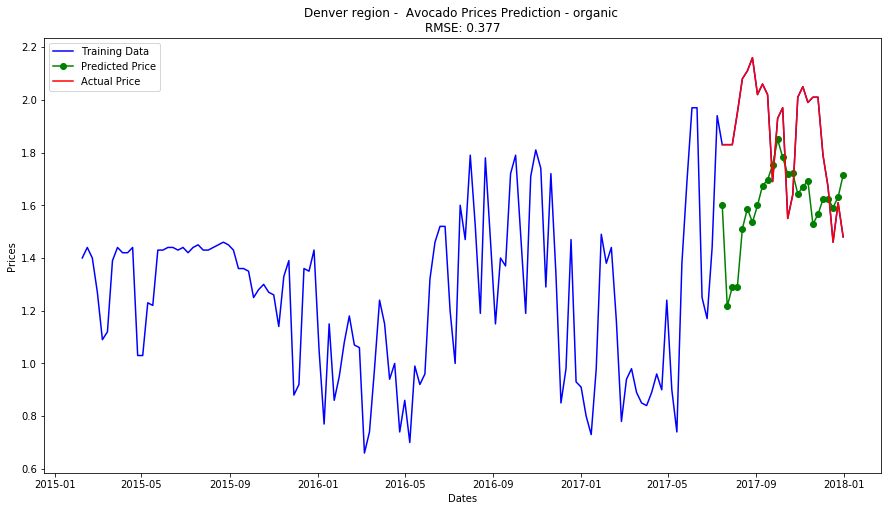

```python
# Getting the time series from train and test dataframes
train_dates = train.loc[(train.region==region), 'date']
test_dates = all_preds.loc[(all_preds.fold=='fold_4')&(all_preds.region==region), 'date']
train_values = train.loc[(train.region==region), 'averageprice']
test_values = all_preds.loc[(all_preds.fold=='fold_4')&(all_preds.region==region), 'actual_price']
test_predictions = all_preds.loc[(all_preds.fold=='fold_4')&(all_preds.region==region), 'predicted_price']

# Getting the error
rmse = round(np.sqrt(mean_squared_error(test_values,test_predictions)),3)
# Plotting the predictions
fig, ax = plt.subplots(1, 1, figsize=(15, 8));
ax.plot(train_dates,train_values, color='blue', label='Training Data');
ax.plot(test_dates, test_predictions, color='green', marker='o',label='Predicted Price');

ax.plot(test_dates, test_values, color='red', label='Actual Price');
ax.set_title(f'{region} region -  Avocado Prices Prediction - {avocado_type} \nRMSE: {rmse}');
ax.set_xlabel('Dates');
ax.set_ylabel('Prices');
ax.legend();
```

# Final Model

```python
# Predicting for test set and visualization
params = {
'learning_rate':0.05,
'n_estimators': 200,
'colsample_bytree': 0.8,
'gamma': 0.3, 'max_depth': 7,
'min_child_weight': 4,
'subsample': 0.6
}
model = XGBRegressor(**params)
model.fit(X,y)
test_preds = model.predict(test[X.columns])
test['predicted_price'] = test_preds
```

# Visulaization of prediction - Test

```python
X.region = le.inverse_transform(X.region)
test.region = le.inverse_transform(test.region)
```

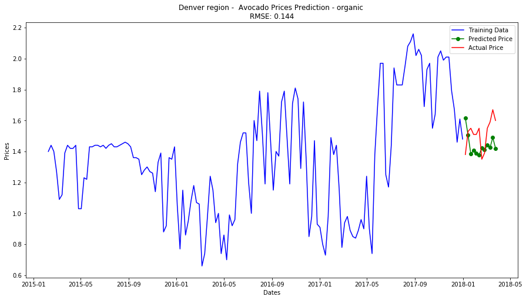

```python
# Getting the time series from train and test dataframes
train_dates = train.loc[(train.region==region), 'date']
test_dates = test.loc[(test.region==region), 'date']
train_values = train.loc[(train.region==region), 'averageprice']
test_values = test.loc[(test.region==region), 'averageprice']
test_predictions = test.loc[(test.region==region), 'predicted_price']

# Getting the error
rmse = round(np.sqrt(mean_squared_error(test_values,test_predictions)),3)
# Plotting the predictions
fig, ax = plt.subplots(1, 1, figsize=(15, 8));
ax.plot(train_dates,train_values, color='blue', label='Training Data');
ax.plot(test_dates, test_predictions, color='green', marker='o',label='Predicted Price');

ax.plot(test_dates, test_values, color='red', label='Actual Price');
ax.set_title(f'{region} region -  Avocado Prices Prediction - {avocado_type} \nRMSE: {rmse}');
ax.set_xlabel('Dates');
ax.set_ylabel('Prices');
ax.legend();
```

# Feature Importance

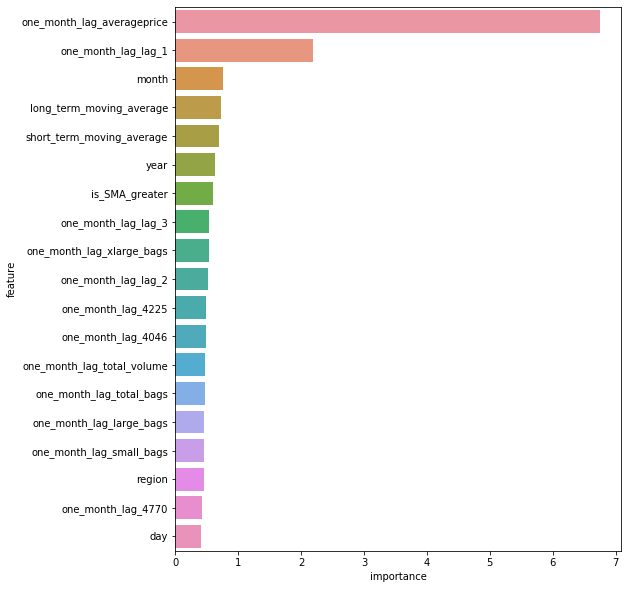

```python
importance = model.get_booster().get_score(importance_type= 'gain')
importance_df = pd.DataFrame(list(importance.items()), columns = ['feature','importance'])
importance_df = importance_df.sort_values('importance',ascending=False)
plt.figure(figsize=(8,10));
sns.barplot(importance_df.importance,importance_df.feature);
```

# Shapley values

```python
import shap
import warnings
explainer = shap.TreeExplainer(model)
expected_value = explainer.expected_value
if isinstance(expected_value, list):
    expected_value = expected_value[1]
print(f"Explainer expected value: {expected_value}")
```

```
Explainer expected value: 1.663622479157766
```

```python
test.region = le.transform(test.region)
X_features = test[X.columns]

with warnings.catch_warnings():
    warnings.simplefilter("ignore")
    shap_values = explainer.shap_values(X_features)
    shap_interaction_values = explainer.shap_interaction_values(X_features)
if isinstance(shap_interaction_values, list):
    shap_interaction_values = shap_interaction_values[1]
```

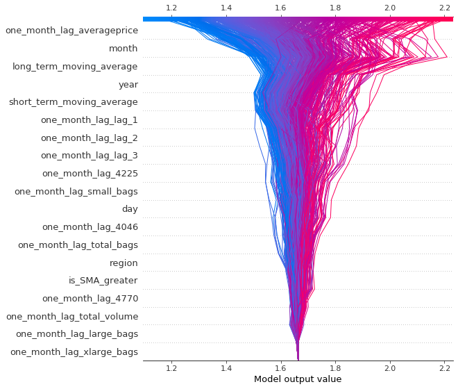

```python
shap.decision_plot(expected_value, shap_values, X_features)
```

> **Shapley values analysis also shows that time related variables are more important for the model in predicting the prices, especially the lag values**

# Future Prediction

```python
future_preds = model.predict(future[X.columns])
future['predicted_price'] = future_preds
```

```python
test.region = le.inverse_transform(test.region)
future.region = le.inverse_transform(future.region)
```

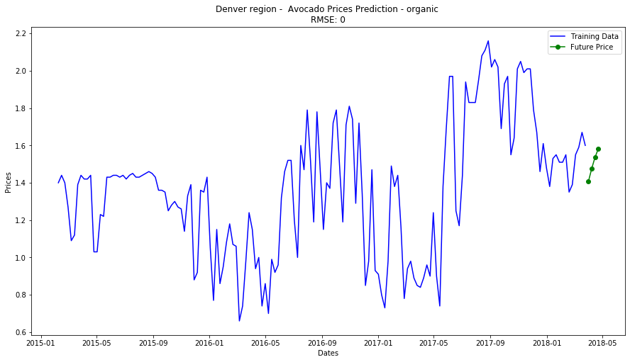

```python
# Getting the time series from train and test dataframes
train_dates = final_train.loc[(final_train.region==region), 'date']
future_dates = future.loc[(future.region==region), 'date']
train_values = final_train.loc[(final_train.region==region), 'averageprice']
future_values = future.loc[(future.region==region), 'predicted_price']

# Getting the error
rmse = 0#round(np.sqrt(mean_squared_error(test_values,test_predictions)),3)
# Plotting the predictions
fig, ax = plt.subplots(1, 1, figsize=(15, 8));
ax.plot(train_dates,train_values, color='blue', label='Training Data');
ax.plot(future_dates, future_values, color='green', marker='o',label='Future Price');

ax.set_title(f'{region} region -  Avocado Prices Prediction - {avocado_type} \nRMSE: {rmse}');
ax.set_xlabel('Dates');
ax.set_ylabel('Prices');
ax.legend();
```

```python
future.loc[(future.region==region), ['date','region','type','predicted_price']]
```

|  | date | region | type | predicted_price |
| --- | --- | --- | --- | --- |
| 50 | 2018-04-01 | Denver | organic | 1.408445 |
| 84 | 2018-04-08 | Denver | organic | 1.475991 |
| 106 | 2018-04-15 | Denver | organic | 1.535271 |
| 203 | 2018-04-22 | Denver | organic | 1.580462 |